# SVM and KNN on Credit Approval

Alfred Ka Chau Tang

10/5/2020

```r
#install.packages("kernlab")
library(kernlab)
#install.packages("kknn")
library(kknn)
```

# Data Hold-Out

```r
data <- read.delim("credit.txt", header = TRUE, stringsAsFactors = FALSE)
# The hold-out method
test_mask <- sample(nrow(data), round(nrow(data) * 0.2))
test_data <- data[test_mask,]
nontest_data <- data[-test_mask,]
```

# Support Vector Machine (SVM) Model

## (1) K-Fold Cross-Validation for Hyperparameter Tuning

```r
TuneSVMByKFCV <- function(data, C, kernel, k_fold) {
  folds <- cut(seq(1, nrow(data)), breaks = k_fold, labels = FALSE)
  data_shuffled <- data[sample(nrow(data)),]
  fold_acc <- rep(0, k_fold)
  for (i in 1:k_fold) {
    mask <- which(folds == i, arr.ind = TRUE)
    valid_data <- data_shuffled[mask,]
    train_data <- data_shuffled[-mask,]
    svm_model <- ksvm(as.matrix(train_data[, 1:10]),
                      as.factor(train_data[, 11]),
                      type = "C-svc", kernel = kernel,
                      C = C, scale = TRUE)
    pred <- predict(svm_model, valid_data[, 1:10])
    fold_acc[i] <- sum(pred == valid_data[, 11])
  }
  acc <- sum(fold_acc) / nrow(data)
  return(acc)
}
```

```r
rates <- c(0.00001, 0.0001, 0.001, 0.01, 0.1, 1, 10, 100, 1000)
svm_line_acc <- rep(0, length(rates))
svm_poly_acc <- rep(0, length(rates))
for (i in 1:length(rates)) {
  svm_line_acc[i] <- TuneSVMByKFCV(nontest_data, rates[i], "vanilladot", 10)
  svm_poly_acc[i] <- TuneSVMByKFCV(nontest_data, rates[i], "polydot", 10)
}
```

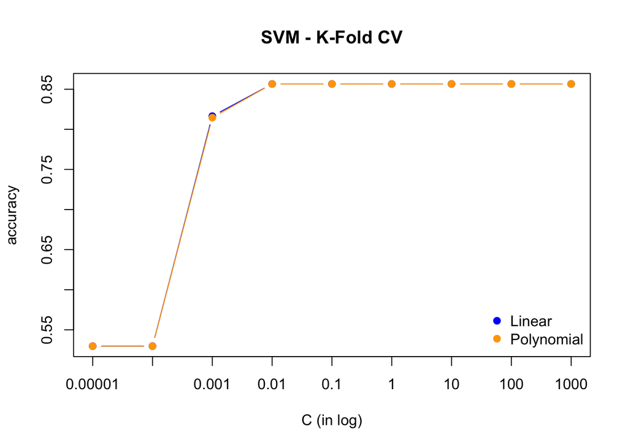

```r
plot(log(rates), svm_line_acc, type = "b", col = "blue", pch = 19, xlab = "C (in log)" , ylab="accuracy", main = "SVM - K-Fold CV", xaxt = "n")
lines(log(rates), svm_poly_acc, type = "b", col = "orange", pch = 19)
legend("bottomright", legend = c("Linear", "Polynomial"), col = c("blue", "orange"), pch = c(19,19), bty = "n")
axis(1,at = log(rates),
     labels = c("0.00001", "0.0001", "0.001", "0.01",
                "0.1", "1", "10", "100", "1000"))
```

It is shown by the above plot that there is no significant difference between linear and polynomial kernels in terms of accuracy, so there is probably a linear pattern in the data. The highest accuracy is attained when C is 0.01 or above. Thus, the best SVM model is built with C = 0.01 with linear kernel, because of its simplicity with comparable performance to models with higher Cs and polynomial kernel.

### (2) Leave-One-Out Cross Validation for Hyperparameter Tuning

```r
# -----------------------------------------------------------------------
# TuneSVMLineByLOOCV <- function(data, C) {
#   PredictByksvm <- function(x) {
#     # All nearest neighbors except the data point itself are counted
#     svm_model <- ksvm(as.matrix(data[-x, 1:10]),
#                       as.factor(data[-x, 11]),
#                       type = "C-svc", kernel = "vanilladot",
#                       C = C, scale = TRUE)
#     pred <- predict(svm_model, data[x, 1:10])
#     return(pred)
#   }
#
#   n_seq <- seq(1, nrow(data))
#   preds <- sapply(n_seq, PredictByksvm)
#   acc <- sum(preds == data[, 11]) / nrow(data)
#   return(acc)
# }
#
# TuneSVMPolyByLOOCV <- function(data, C) {
#   PredictByksvm <- function(x) {
#     # All nearest neighbors except the data point itself are counted
#     svm_model <- ksvm(as.matrix(data[-x, 1:10]),
#                       as.factor(data[-x, 11]),
#                       type = "C-svc", kernel = "polydot",
#                       C = C, scale = TRUE)
#     pred <- predict(svm_model, data[x, 1:10])
#     return(pred)
#   }
#
#   n_seq <- seq(1, nrow(data))
#   preds <- sapply(n_seq, PredictByksvm)
#   acc <- sum(preds == data[, 11]) / nrow(data)
#   return(acc)
# }
# -----------------------------------------------------------------------
```

```r
# -----------------------------------------------------------------------
# svm_line_acc2 <- rep(0, length(rates))
# svm_poly_acc2 <- rep(0, length(rates))
# for (i in 1:length(rates)) {
#   svm_line_acc2[i] <- TuneSVMLineByLOOCV(nontest_data, i)
#   svm_poly_acc2[i] <- TuneSVMPolyByLOOCV(nontest_data, i)
# }
#
# plot(svm_line_acc2, type = "b", col = "blue", pch = 19, xlab = "K" , ylab="accuracy", main = "SVM - LOOCV")
# lines(svm_poly_acc2, type = "b", col = "orange", pch = 19)
# legend("bottomright", legend = c("Manhattan", "Euclidean"), col = c("blue", "orange"), pch = c(19,19), bty = "n")
# -----------------------------------------------------------------------
```

## K-Nearest Neighbor (KNN) Model

### (1) K-fold Cross Validation for Hyperparameter Tuning

```r
TuneKNNByKFCV <- function(data, k, k_fold, d) {
  folds <- cut(seq(1, nrow(data)), breaks = k_fold, labels = FALSE)
  data_shuffled <- data[sample(nrow(data)),]
  fold_acc <- rep(0, k_fold)
  for (i in 1:k_fold) {
    mask <- which(folds == i, arr.ind = TRUE)
    valid_data <- data_shuffled[mask,]
    train_data <- data_shuffled[-mask,]
    knn_model <- kknn(R1 ~ ., train_data, valid_data, distance = d, k = k, scale = TRUE)
    fold_acc[i] <- sum(as.integer(knn_model$fitted.values + 0.5) == valid_data[,11])
  }
  acc <- sum(fold_acc) / nrow(data)
  return(acc)
}
```

```r
knn_manhattan_acc <- rep(0, 30)
knn_euclidean_acc <- rep(0, 30)
for (k in 1:30) {
  knn_manhattan_acc[k] <- TuneKNNByKFCV(nontest_data, k, 10, 1)
  knn_euclidean_acc[k] <- TuneKNNByKFCV(nontest_data, k, 10, 2)
}
```

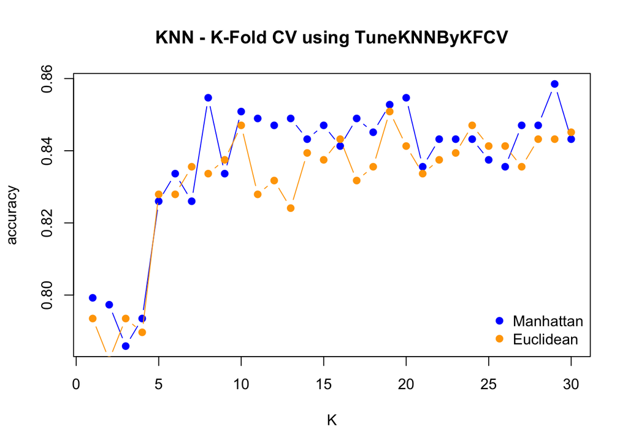

```r
plot(knn_manhattan_acc, type = "b", col = "blue", pch = 19, xlab = "K" , ylab="accuracy", main = "KNN - K-Fold CV using TuneKNNByKFCV")
lines(knn_euclidean_acc, type = "b", col = "orange", pch = 19)
legend("bottomright", legend = c("Manhattan", "Euclidean"), col = c("blue", "orange"), pch = c(19,19), bty = "n")
```

In fact, the above K-fold Cross Validation can be accomplished by the built-in function cv.kknn.

```r
knn_manhattan_acc2 <- rep(0, 30)
knn_euclidean_acc2 <- rep(0, 30)
for (k in 1:30) {
  knn_kfcv_man <- cv.kknn(R1 ~ ., nontest_data, kcv = 10, k = k, distance = 1, scale = TRUE)
  knn_kfcv_euc <- cv.kknn(R1 ~ ., nontest_data, kcv = 10, k = k, distance = 2, scale = TRUE)
  pred_man <- as.integer(knn_kfcv_man[[1]][,2] + 0.5)
  pred_euc <- as.integer(knn_kfcv_euc[[1]][,2] + 0.5)
  knn_manhattan_acc2[k] <- sum(pred_man == nontest_data[,11]) / nrow(nontest_data)
  knn_euclidean_acc2[k] <- sum(pred_euc == nontest_data[,11]) / nrow(nontest_data)
}
```

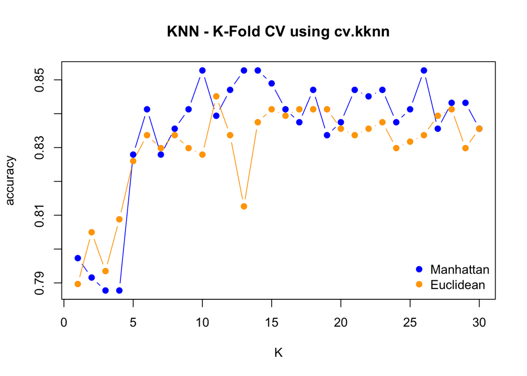

```r
plot(knn_manhattan_acc2, type = "b", col = "blue", pch = 19,  xlab = "K" , ylab="accuracy", main = "KNN - K-Fold CV using cv.kknn")
lines(knn_euclidean_acc2, type = "b", col = "orange", pch = 19)
legend("bottomright", legend = c("Manhattan", "Euclidean"), col = c("blue", "orange"), pch = c(19,19), bty = "n")
```

Regardless of using my own function or the built-in one, the above two plots show that the KNN model performs better on this data set when K >= 5 and using Manhattan distance. Despite the fluctuations with respect to the accuracy, there is no significant difference between the Ks that are near 15.

### (2) Leave-One-Out Cross Validation for Hyperparameter Tuning

Given the small sample size, we can make the best use of the training set by utilizing leave-one-out cross validation, i.e. using all the data points except itself to predict each of them.

```r
TuneKNNByLOOCV <- function(data, k, d) {
  PredictBykknn <- function(x) {
    # All nearest neighbors except the data point itself are counted
    knn_model <- kknn(R1 ~ ., data[-x,], data[x,],
                      k = k, distance = d, scale = TRUE)
    # kknn returns the proportion of the k-nearest neighbors that are 1
    pred <- as.integer(knn_model$fitted.values + 0.5)
    return(pred)
  }

  n_seq <- seq(1, nrow(data))
  preds <- sapply(n_seq, PredictBykknn)

  # -----------------------------------------------------------------------
  # the for-loop version with the same logic
  # given the number of loops (i.e. sample size), it has slower performance
  # for (i in 1:nrow(data)) {
  #   knn_model <- kknn(R1 ~ ., data[-i, ], data[i, ],
  #                     k = k, distance = d, scale = TRUE)
  #   pred[i] <- as.integer(knn_model$fitted.values + 0.5)
  # }
  # -----------------------------------------------------------------------

  acc <- sum(preds == data[, 11]) / nrow(data)
  return(acc)
}
```

```r
knn_manhattan_acc3 <- rep(0, 30)
knn_euclidean_acc3 <- rep(0, 30)
for (k in 1:30) {
  knn_manhattan_acc3[k] <- TuneKNNByLOOCV(nontest_data, k, 1)
  knn_euclidean_acc3[k] <- TuneKNNByLOOCV(nontest_data, k, 2)
}
```

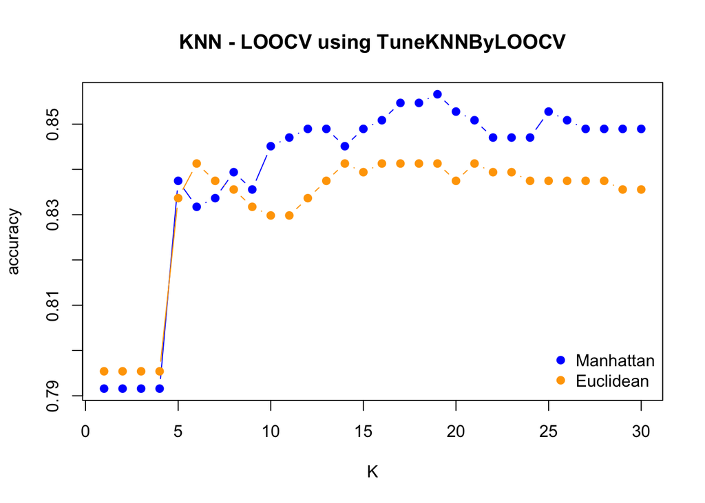

```r
plot(knn_manhattan_acc3, type = "b", col = "blue", pch = 19, xlab = "K" , ylab="accuracy", main = "KNN - LOOCV using TuneKNNByLOOCV")
lines(knn_euclidean_acc3, type = "b", col = "orange", pch = 19)
legend("bottomright", legend = c("Manhattan", "Euclidean"), col = c("blue", "orange"), pch = c(19,19), bty = "n")
```

Again, the above leave-one-out cross validation can be done by the built-in function train.kknn, which is in fact computationally very efficient and faster than cv.kknn which does not yet contain the test of different models.

```r
kmax = 30
knn_loocv_man <- train.kknn(R1 ~ ., nontest_data,
                            kmax = kmax, distance = 1, scale = TRUE)
knn_loocv_euc <- train.kknn(R1 ~ ., nontest_data,
                            kmax = kmax, distance = 2, scale = TRUE)
knn_manhattan_acc4 <- rep(0, kmax)
knn_euclidean_acc4 <- rep(0, kmax)
for (k in 1:kmax) {
  pred_man <- as.integer(knn_loocv_man$fitted.values[[k]] + 0.5)
  pred_euc <- as.integer(knn_loocv_euc$fitted.values[[k]] + 0.5)
  knn_manhattan_acc4[k] <- sum(pred_man == nontest_data[,11]) / nrow(nontest_data)
  knn_euclidean_acc4[k] <- sum(pred_euc == nontest_data[,11]) / nrow(nontest_data)
}
```

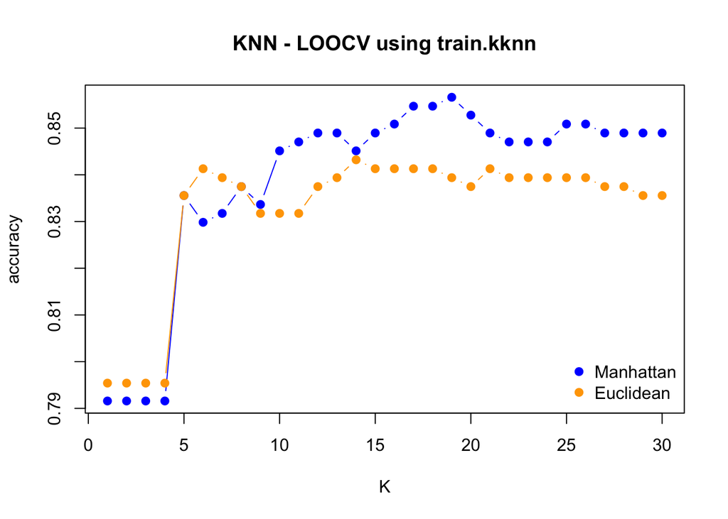

```r
plot(knn_manhattan_acc4, type = "b", col = "blue", pch = 19, xlab = "K" , ylab="accuracy", main = "KNN - LOOCV using train.kknn")
lines(knn_euclidean_acc4, type = "b", col = "orange", pch = 19)
legend("bottomright", legend = c("Manhattan", "Euclidean"), col = c("blue", "orange"), pch = c(19,19), bty = "n")
```

Similar to what we observed from K-fold cross validation, the above two plots show that the KNN model performs better on this data set when K >= 5 and using Manhattan distance. Although the highest accuracy is attained with a different K given the randomness, odd number of K is preferred in case that a tie between the two classes exists.

# The Best Model

```r
svm_best_acc <- max(cbind(svm_line_acc, svm_poly_acc))
svm_best_acc
```

```
## [1] 0.8565966
```

```r
knn_best_acc <- max(cbind(knn_manhattan_acc, knn_manhattan_acc2, knn_manhattan_acc3, knn_manhattan_acc4))
knn_best_acc
```

```
## [1] 0.8585086
```

```r
best_model <- ksvm(as.matrix(nontest_data[, 1:10]),
                   as.factor(nontest_data[, 11]),
                   type = "C-svc", kernel = "vanilladot",
                   C = 0.01, scale = TRUE)
pred <- predict(best_model, test_data[, 1:10])
sum(pred == test_data[, 11]) / nrow(test_data)
```

```
## [1] 0.8854962
```